# Regression Models Course Project

## Summary

**In this analysis we wish to study the effect of transmission on miles per gallon.We conducted t test which alludes that there is significant difference in mpg for automatic and manual tranmission.**

**The fitted model suggest that estimated mpg for manual transmission is 2.9358 more than the estimated mpg for automatic transmission,provided the other variables are kept constant.**

### Data processing

```r
library(dplyr)
```

```r
library(ggplot2)
data(mtcars)
mtcars$am<-as.factor(mtcars$am)
levels(mtcars$am)=c("at","mt")
```

The mtcars dataset has been loaded to be analysed.The column am(transmission) has been tranformed into factor with levels at(automatic) and mt(manual).

### Exploratory Data Analysis.

In this analysis we specifically wish to answer the question-Is an automatic or manual transmission better for MPG?.Hence our exploratory analysis will revolve aroung mpg and am(transmission).

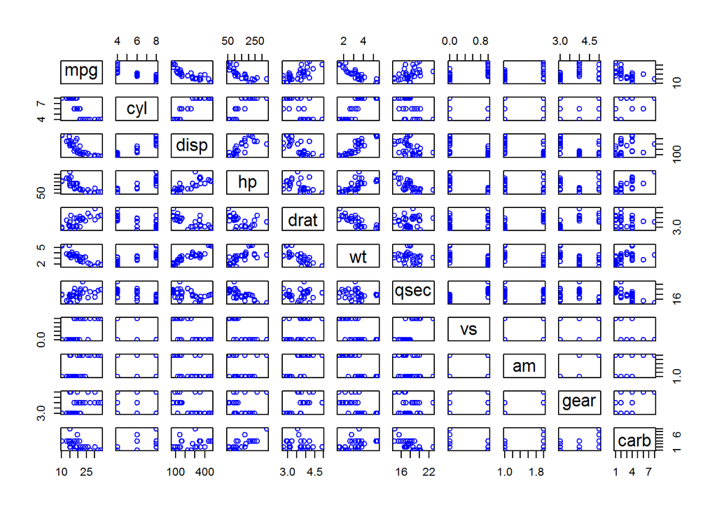

```r
pairs(mtcars,col="blue")
```

The above pair plot shows potential relationships between different variables of the mtcars dataset.

```r
str(mtcars)
```

```
## 'data.frame':    32 obs. of  11 variables:
##  $ mpg : num  21 21 22.8 21.4 18.7 18.1 14.3 24.4 22.8 19.2 ...
##  $ cyl : num  6 6 4 6 8 6 8 4 4 6 ...
##  $ disp: num  160 160 108 258 360 ...
##  $ hp  : num  110 110 93 110 175 105 245 62 95 123 ...
##  $ drat: num  3.9 3.9 3.85 3.08 3.15 2.76 3.21 3.69 3.92 3.92 ...
##  $ wt  : num  2.62 2.88 2.32 3.21 3.44 ...
##  $ qsec: num  16.5 17 18.6 19.4 17 ...
##  $ vs  : num  0 0 1 1 0 1 0 1 1 1 ...
##  $ am  : Factor w/ 2 levels "at","mt": 2 2 2 1 1 1 1 1 1 1 ...
##  $ gear: num  4 4 4 3 3 3 3 4 4 4 ...
##  $ carb: num  4 4 1 1 2 1 4 2 2 4 ...
```

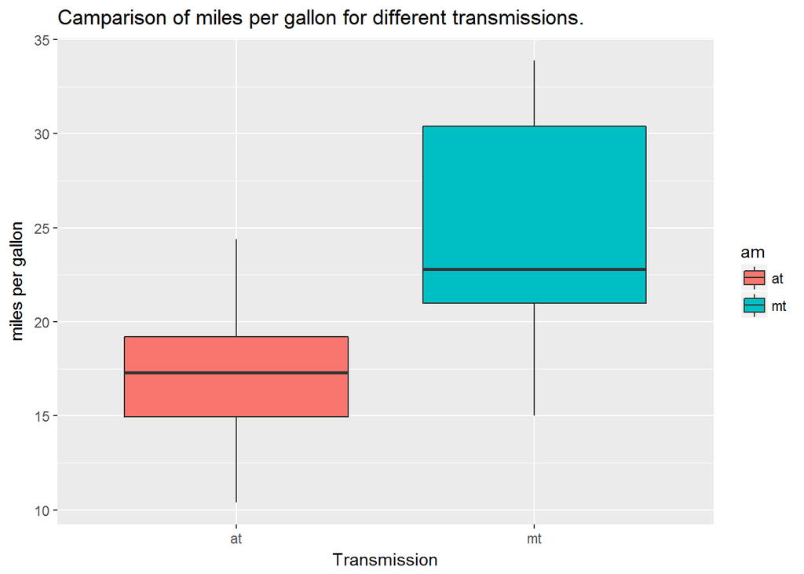

```r
ggplot(mtcars,aes(am,mpg,fill=am))+geom_boxplot()+labs(x="Transmission")+labs(y="miles per gallon")+labs(title="Camparison of miles per gallon for different transmissions.")
```

*Miles per gallon seems to differ according to transmission.Hence formal inference should be conducted over this idea.*

### Formal Hypothesis testing

```r
mpg_at<-select(filter(mtcars,am=="at"),mpg)
mpg_mt<-select(filter(mtcars,am=="mt"),mpg)
t.test(mpg_at,mpg_mt)
```

```
##
##  Welch Two Sample t-test
##
## data:  mpg_at and mpg_mt
## t = -3.7671, df = 18.332, p-value = 0.001374
## alternative hypothesis: true difference in means is not equal to 0
## 95 percent confidence interval:
##  -11.280194  -3.209684
## sample estimates:
## mean of x mean of y
##  17.14737  24.39231
```

The p value is less than 0.05 and hence we fail to accept the null hypothesis.The T test alludes to statistically significant difference between mpg of automatic and manual transmission.

### Linear Models

**Model 1**

```r
fit1<-lm(mpg~am,data=mtcars)
summary(fit1)
```

```
##
## Call:
## lm(formula = mpg ~ am, data = mtcars)
##
## Residuals:
##     Min      1Q  Median      3Q     Max
## -9.3923 -3.0923 -0.2974  3.2439  9.5077
##
## Coefficients:
##             Estimate Std. Error t value Pr(>|t|)
## (Intercept)   17.147      1.125  15.247 1.13e-15 ***
## ammt           7.245      1.764   4.106 0.000285 ***
## ---
## Signif. codes:  0 '***' 0.001 '**' 0.01 '*' 0.05 '.' 0.1 ' ' 1
##
## Residual standard error: 4.902 on 30 degrees of freedom
## Multiple R-squared:  0.3598, Adjusted R-squared:  0.3385
## F-statistic: 16.86 on 1 and 30 DF,  p-value: 0.000285
```

In this models both the intercept and coefficient are statistically significant.Acoording to the model the estimated mpg for manual transmission is 7.245 more than the automatic transmission.The R^2 of the model is 0.3598,which alludes that this model only explains 35.98% of the relationship.

**Model 2**

```r
fit2<-step(lm(mpg~.,data=mtcars),trace=0)
summary(fit2)
```

```
##
## Call:
## lm(formula = mpg ~ wt + qsec + am, data = mtcars)
##
## Residuals:
##     Min      1Q  Median      3Q     Max
## -3.4811 -1.5555 -0.7257  1.4110  4.6610
##
## Coefficients:
##             Estimate Std. Error t value Pr(>|t|)
## (Intercept)   9.6178     6.9596   1.382 0.177915
## wt           -3.9165     0.7112  -5.507 6.95e-06 ***
## qsec          1.2259     0.2887   4.247 0.000216 ***
## ammt          2.9358     1.4109   2.081 0.046716 *
## ---
## Signif. codes:  0 '***' 0.001 '**' 0.01 '*' 0.05 '.' 0.1 ' ' 1
##
## Residual standard error: 2.459 on 28 degrees of freedom
## Multiple R-squared:  0.8497, Adjusted R-squared:  0.8336
## F-statistic: 52.75 on 3 and 28 DF,  p-value: 1.21e-11
```

The step algorithm picks the variables which have highest effect on the mpg for the model.Acoording to this model transmission,weight and qsec(1/4 mile time) seems to have highest effect on mpg.  
*This model suggests that mpg for manual transmission is 2.9358 more than mpg of automatic transmission,provided the other variables are kept constant.*  
The adjusted R^2 suggests that around 83.36% of the relationship is explained by the model.

### Anova testing

```r
anova(fit1,fit2)
```

```
## Analysis of Variance Table
##
## Model 1: mpg ~ am
## Model 2: mpg ~ wt + qsec + am
##   Res.Df    RSS Df Sum of Sq      F   Pr(>F)
## 1     30 720.90
## 2     28 169.29  2    551.61 45.618 1.55e-09 ***
## ---
## Signif. codes:  0 '***' 0.001 '**' 0.01 '*' 0.05 '.' 0.1 ' ' 1
```

According to the anova testing,fit2 is signifiantly better model tha fit1.It explains around 83.36% of the relationship.

### Residual testing for the chosen model.

residual plots

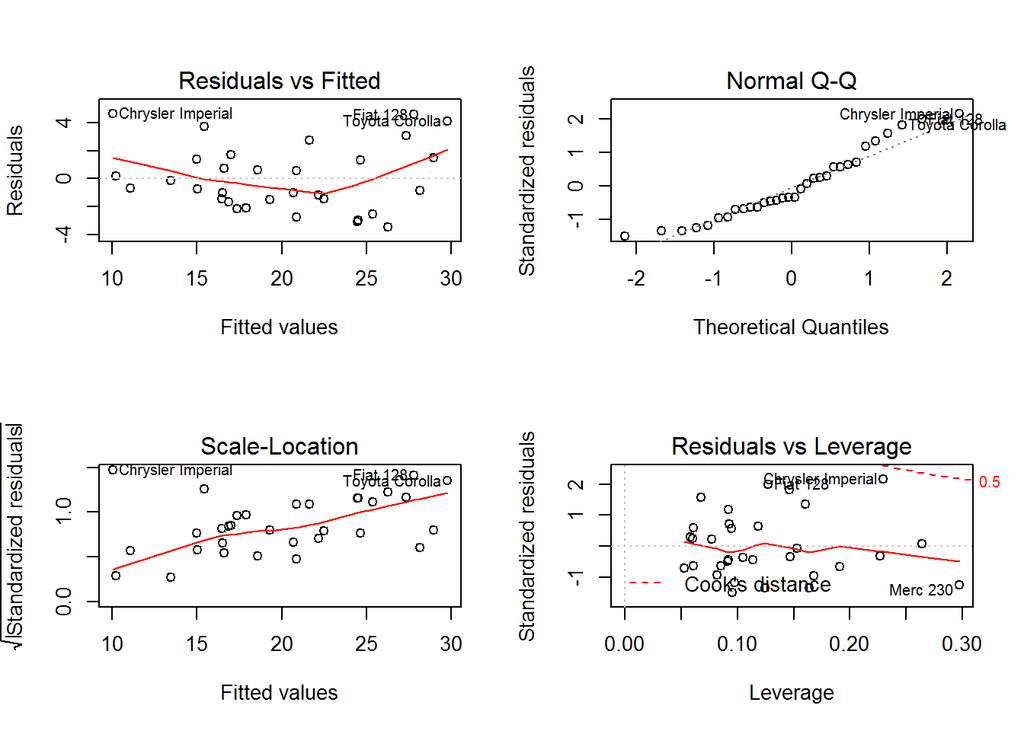

```r
par(mfrow=c(2,2))
plot(fit2)
```

**Shapiro wilk test**

```r
shapiro.test(fit2$residuals)
```

```
##
##  Shapiro-Wilk normality test
##
## data:  fit2$residuals
## W = 0.9411, p-value = 0.08043
```

The p value is 0.08043 and hence we fail to reject the null hypothesis.The null hypothesis suggest the normality of the residuals.

## Conclusion

**The fitted model suggest that estimated mpg for manual transmission is 2.9358 more than the estimated mpg for automatic transmission,when other variables are kept constant.**